# Bandits

## Power computations

```r
pwr.norm.test(d=0.25, sig.level=0.05, power=0.9)$n
```

```
## [1] 168
```

```r
pwr.norm.test(d=0.25, sig.level=0.05, power=0.95)$n
```

```
## [1] 208
```

```r
pwr.norm.test(d=0.5, sig.level=0.05, power=0.95)$n
```

```
## [1] 52
```

```r
power.prop.test(p1=0.04,p2=0.05,sig.level = 0.05,power = 0.95)
```

```
##
##      Two-sample comparison of proportions power calculation
##
##               n = 11165.99
##              p1 = 0.04
##              p2 = 0.05
##       sig.level = 0.05
##           power = 0.95
##     alternative = two.sided
##
## NOTE: n is number in *each* group
```

```r
power.prop.test(p1=0.04,p2=0.08,sig.level = 0.05,power = 0.95)
```

```
##
##      Two-sample comparison of proportions power calculation
##
##               n = 913.1595
##              p1 = 0.04
##              p2 = 0.08
##       sig.level = 0.05
##           power = 0.95
##     alternative = two.sided
##
## NOTE: n is number in *each* group
```

## Bayes AB testing

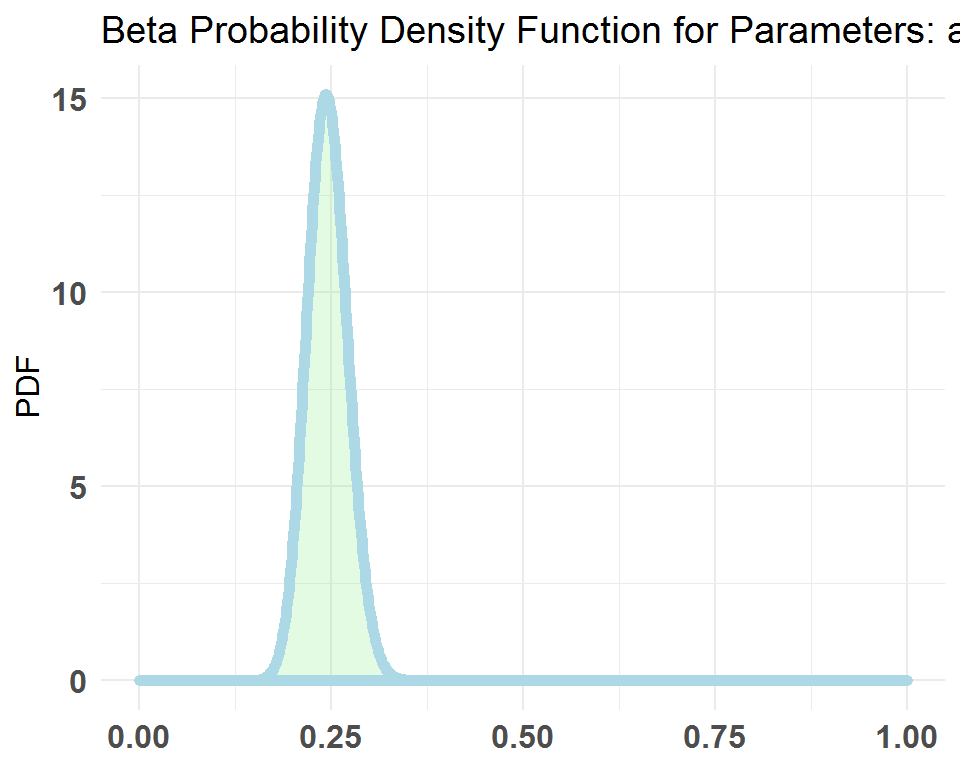

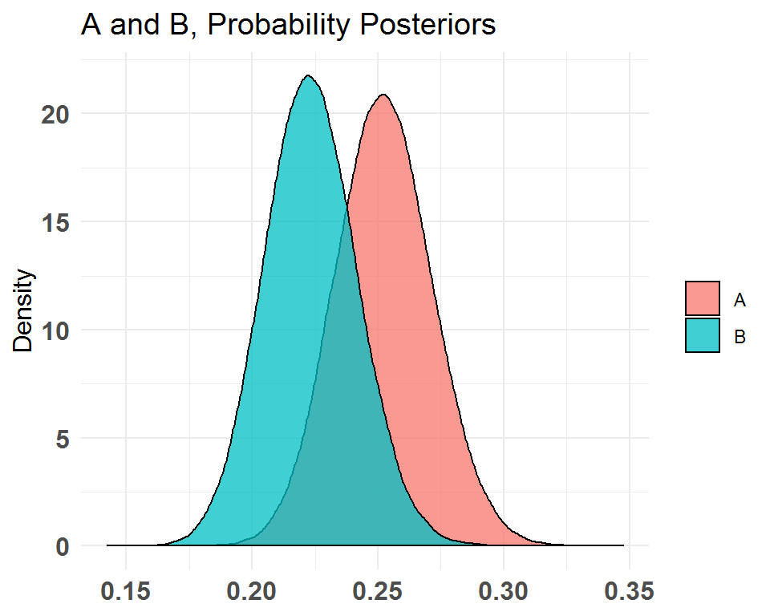

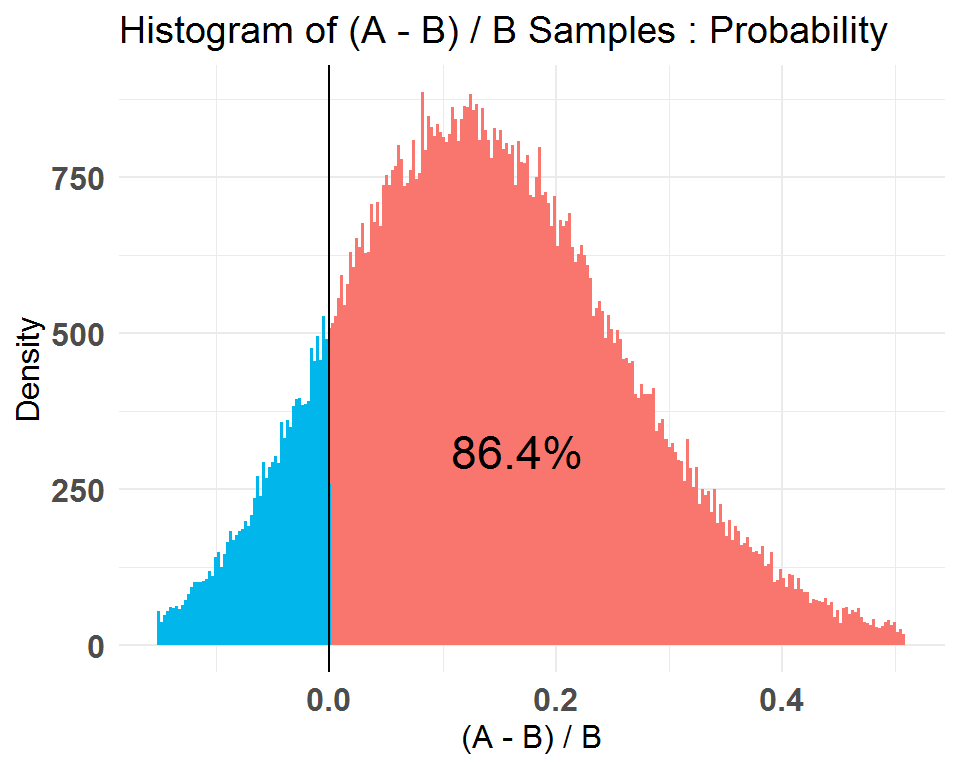

```r
library(bayesAB)

A_binom <- rbinom(250, 1, .25)
B_binom <- rbinom(250, 1, .2)

AB1 <- bayesTest(A_binom, B_binom, priors = c('alpha' = 65, 'beta' = 200), distribution = 'bernoulli')
plot(AB1)
```

Uniform prior:

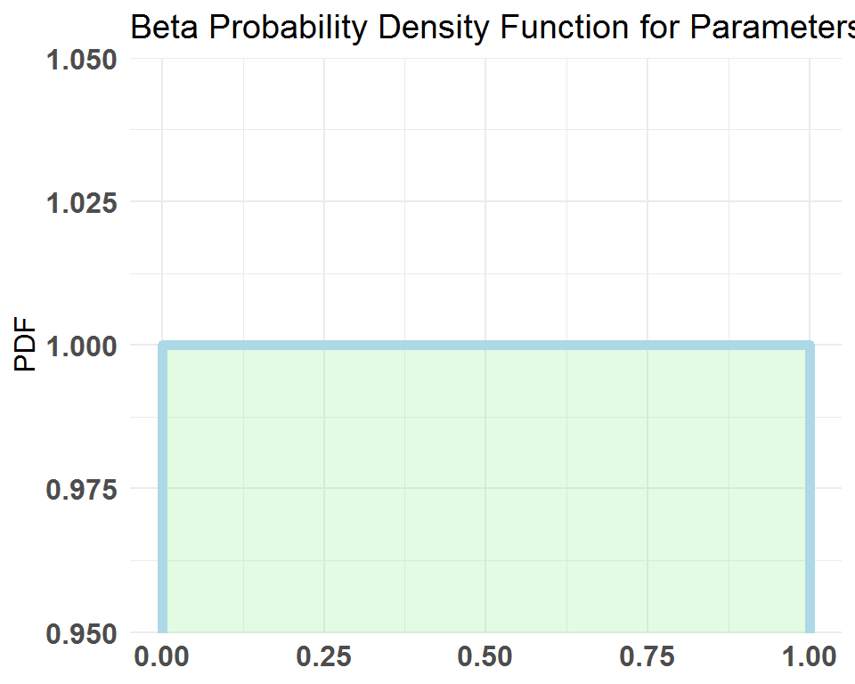

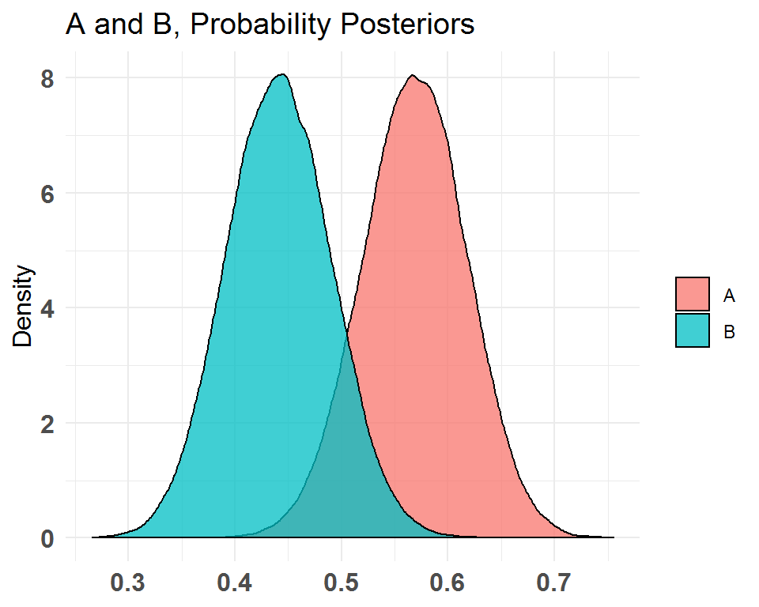

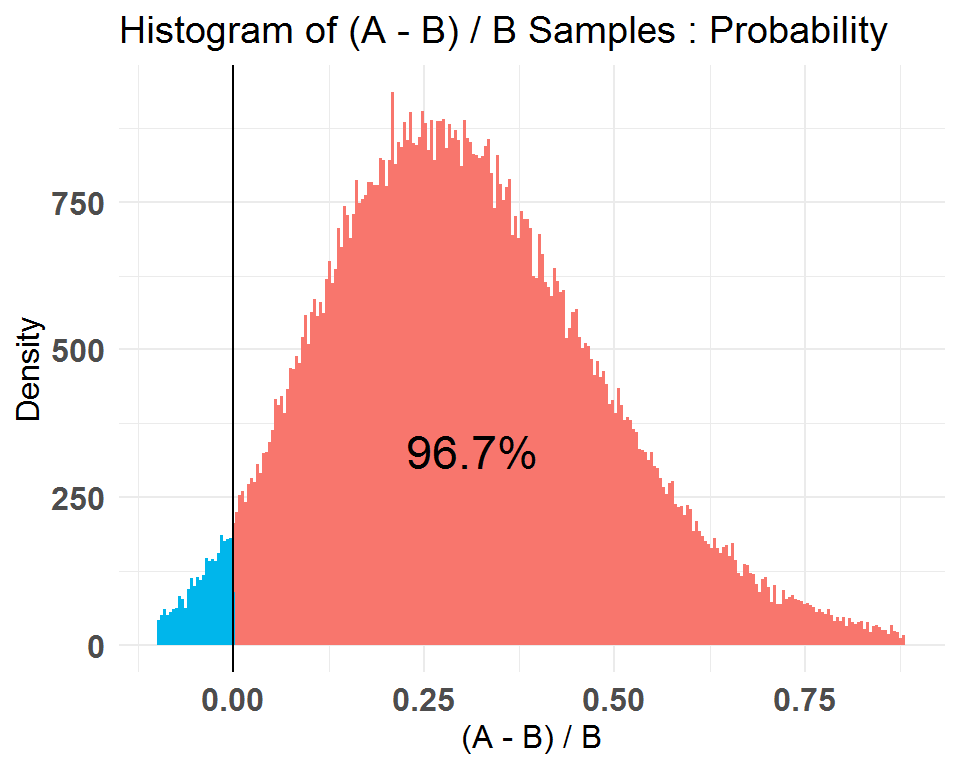

```r
A_binom <- rbinom(100, 1, .55)
B_binom <- rbinom(100, 1, .5)

# Fit bernoulli test
AB1 <- bayesTest(A_binom,
                 B_binom,
                 priors = c('alpha' = 1, 'beta' = 1),
                 distribution = 'bernoulli')

plot(AB1)
```

```r
summary(AB1)
```

```
## Quantiles of posteriors for A and B:
##
## $Probability
## $Probability$A
##        0%       25%       50%       75%      100%
## 0.3607845 0.5357551 0.5689428 0.6017751 0.7558383
##
## $Probability$B
##        0%       25%       50%       75%      100%
## 0.2654394 0.4076538 0.4409099 0.4743133 0.6490560
##
##
## --------------------------------------------
##
## P(A > B) by (0)%:
##
## $Probability
## [1] 0.96694
##
## --------------------------------------------
##
## Credible Interval on (A - B) / B for interval length(s) (0.9) :
##
## $Probability
##        5%       95%
## 0.0262102 0.6363936
##
## --------------------------------------------
##
## Posterior Expected Loss for choosing B over A:
##
## $Probability
## [1] 0.001970389
```

## Optional Stopping

Suppose we are running an A/B test on a new feature. We run the experiment for 20 days, and on each day get about 10,000 impressions. We use the Chi-squared test for the difference between two proportions to test whether the new feature improved click-through rate. Unbeknownst to us, the new feature has absolutely no effect- the clickthrough rate is always .1%.

```r
library(ggplot2)
theme_set(theme_bw())
```

```r
library(plyr)
library(dplyr)
library(tidyr)
library(broom)
library(ggplot2)

# the custom splittestr package, found at
#
#library(splittestr)
#for(f in list.files("extraCode/",full.names = TRUE)) print(f)
for(f in list.files("extraCode/", full.names = TRUE)) source(f)
```

```r
nreps <- 5000

set.seed(2015 - 08 - 07)
sim_no_difference <- data_frame(replicate = seq_len(nreps)) %>%
  mutate(proportion_A = .001,
         effect = 0,
         per_day = 10000) %>%
  perform_simulation(approx = TRUE)

# add chi-squared p-values
sim_no_difference <- sim_no_difference %>%
  mutate(p.value = vectorized_prop_test(sA, nA - sA, sB, nB - sB))
```

```r
last_day_pvals <- sim_no_difference %>%
  filter(day == 20) %>%
  .$p.value
```

```r
plot_paths <- function(dat, color_by = "pass_end", hline = .05,
                       yaxis = "p.value",
                       labels = c("Not Significant", "Significant")) {
  dat %>%
    ggplot(aes_string("day", yaxis, group = "replicate")) +
    geom_line(aes_string(alpha = color_by, color = color_by)) +
    geom_hline(color = "red", yintercept = hline, lty = 2) +
    scale_color_manual(values = c("black", "red"), labels = labels) +
    scale_alpha_manual(values = c(.15, 1), labels = labels) +
    labs(color = "", alpha = "") +
    xlab("Day of experiment")
}
```

If we look at the results on the 20th day, we find that 5 of our simulations fell below our p-value cutoff of .05. The rate at which we falsely call nulls significant is called the [type I error rate](https://en.wikipedia.org/wiki/Type_I_and_type_II_errors). By setting a p-value threshold of .05, we set a goal that that error rate should be 5%, and we (roughly) kept that promise. The system worked!

```r
alpha <- .05

set.seed(3)
subsim_pvalue <- sim_no_difference %>%
  filter(replicate %in% sample(nreps, 100)) %>%
  group_by(replicate) %>%
  mutate(pass_end = last(p.value) < alpha) %>%
  mutate(pass_anywhere = min(p.value) < alpha)

lastdaysig <- subsim_pvalue %>%
  filter(day == 20, p.value < alpha)

plot_paths(subsim_pvalue, hline = alpha) +
  geom_point(color = "red", data = lastdaysig) +
  ylab("P-value")
```

[output not shown]

```r
anywhere_sig <- subsim_pvalue %>%
  filter(p.value < .05) %>%
  slice(1)

subsim_pvalue %>%
  filter(head(cumsum(c(1, p.value) < .05), -1) == 0) %>%
  plot_paths(color_by = "pass_anywhere", hline = alpha) +
  geom_point(color = "red", data = anywhere_sig) +
  ylab("P-value")

min_pvalues <- sim_no_difference %>%
  group_by(replicate) %>%
  summarize(min = min(p.value)) %>%
  .$min
```

[output not shown]

Even though none of the simulations had a real effect, 15 of them drop below the significance cutoff of .05 at some point. If we stopped the experiment right then, we would end up calling them significant- and our Type I error rate goes way up. Our method didn’t keep its promise!

## Regret

Let $y_t =(y_1, \ldots ,y_t)$ denote the sequence of rewards observed up to time $t$. Let $a_t$ denote the arm of the bandit that was played at time $t$ and $\mu_a(\theta)$ denote the expected reward.

Let $\mu^*(\theta)=max_a\{\mu_a(\theta)\}$, the expected reward under the truly optimal arm, and let $n_{at}$ at denote the number of observations that were allocated to arm $a$ at time $t$. Then the expected cumulative regret is

$$L = \sum_{t=1}^T{\sum_{a}{n_{at} \left( \mu^*(\theta) - \mu_a(\theta) \right) }}$$